# OpenGWASDB ukb-b Dense Store — Performance & Validation

Genome-wide · 2,514 UK Biobank analyses · observed-only and reference-completed

Published

August 13, 2026

## Overview

Two **Dense** stores over the **2,514 genome-wide UK Biobank GWAS** in the OpenGWAS `ukb-b` batch:

- an **Observed-Only** store built from the source GWAS-VCFs with inline hg19→hg38 liftover;
- a **Reference-Completed** store whose variant axis is the observed source variants plus EUR LD-panel variants.

This report benchmarks query latency across all access patterns, storage and build cost versus the raw VCFs, and an MR IVW analysis as an end-to-end scientific validation.

| Property | Observed-Only | Reference-Completed |
| --- | --- | --- |
| Analyses (GWAS) | 2,514 | 2,514 |
| Variants (hg38) | 9,847,701 | 11,192,757 |
| Additional panel variants | — | 1,345,056 |
| Associations (dense cells) | 24.8 billion | 28.1 billion |
| Reference assembly | GRCh38 | GRCh38 |

## Storage vs. raw VCF

| Form | Files | Size |
| --- | --- | --- |
| Raw source VCFs (.vcf.gz) | 2,514 files | 425.4 GB |
| OpenGWASDB Dense Observed-Only | single store | **58.0 GB** |
| OpenGWASDB Dense Reference-Completed | single store | **75.2 GB** |

**7.3× smaller** than the source VCFs (58.0 GB vs 425 GB) — one queryable store replacing 2,514 files. The store keeps float16 `z` + `se`, a tabix variant axis, an mmap’d ALID index, and a top-hit index.

The reference-completed store is **17.2 GB larger** than observed-only after adding 1,345,056 panel variants, imputed flags, and completion metadata.

## Build

| Property | Value |
| --- | --- |
| Build time | 3.5 h (12,566 s) |
| Peak memory | ≈43 GB (band-streamed; see issue 043) |
| Pipeline | serial union+liftover → parallel fill (spill) → band-write zarr |

## Query performance

Median of repeated calls after one warm-up, on the full genome-wide stores.

| Pattern | Observed median | Completed median | Completed / observed | Result cells | What it reads |
| --- | --- | --- | --- | --- | --- |
| bulk | 29.65 s | 35.57 s | 1.20× | 8,419,893 → 10,003,315 | One analysis, all variants (`analysis`) |
| phewas | 5.3 ms | 9.7 ms | 1.84× | 1,344 → 2,514 | One variant × all 2,514 analyses (`phewas`) |
| regional | 620.7 ms | 948.3 ms | 1.53× | 5,231,847 → 9,669,654 | All associations in a 1 Mb window (`range_phewas`) |
| tophits | 1.2 ms | 1.8 ms | 1.52× | 7,390 → 8,580 | Significant hits for `ukb-b-10912` (addressed index slice, p<5e-8) |
| random_lookup | 814.7 ms | 679.2 ms | 0.83× | 566 → 909 | 100 variants × 10 analyses (`lookup`) |

`phewas` and the analysis-addressed `top_hits` call are low-millisecond point queries. `bulk` and `regional` scale with the number of cells returned. Top-hit tiers are packed by analysis index and canonical genomic position, with an offset table mapping each analysis directly to one contiguous slice. The reference-completed index stores the `imputed` flag alongside `z`/`se`, avoiding random reads into `data.zarr/imputed`.

### `random_lookup` across request sizes

The table above reports one fixed `random_lookup` shape (100 variants × 10 analyses). The table below re-measures `lookup` on the observed-only store across four request shapes, with no competing background job on the host, to separate the row-axis cost (scattered variants, each its own row-chunk) from the column-axis cost (requested analyses).

| Variants | Analyses | Cells requested | Median | p95 | Result cells |
| --- | --- | --- | --- | --- | --- |
| 1 | 1 | 1 | 2.3 ms | 3.5 ms | 1 |
| 100 | 10 | 1,000 | 777.9 ms | 945.5 ms | 553 |
| 10 | 100 | 1,000 | 100.0 ms | 103.7 ms | 499 |
| 100 | 500 | 50,000 | 898.0 ms | 929.3 ms | 29,153 |

7 repetitions per shape after one warm-up, store: `/data/opengwasdb/wip/ukb-b.opengwasdb`.

Latency tracks the number of **scattered row-chunks touched**, not the number of requested cells: 100 variants × 10 analyses (777.9 ms) and 100 variants × 500 analyses (898.0 ms) cost almost the same despite a 50× difference in requested cells, because both scatter 100 variants across 100 separate row-chunks. 10 variants × 100 analyses (100.1 ms) is far cheaper with the *same* 1,000 requested cells, because it only touches 10 row-chunks. The single-cell lookup (2.3 ms) is close to the store’s point-query floor. This is the read pattern issue opengwasdb#52 targets: `lookup` currently reads full analysis-width column-chunks per selected row rather than only the column-chunks intersecting the requested analyses.

### Analysis-major top-hit experiment

The previous implementation materialised the complete 5.5–6.4 million-entry tier and filtered it in Python. The experiment below holds the analysis, threshold, result ordering, and result count constant while varying only the one-dimensional Zarr chunk length. Each figure is based on 10 timed warm-cache repetitions after a warm-up. “First read” is reported separately as the first call after reopening the store; it is not claimed to be a controlled cold-cache measurement.

#### Observed-Only

| Chunk | First read | Selected median | Selected p95 | Global median | Index size | Repack |
| --- | --- | --- | --- | --- | --- | --- |
| 1,024 | 2.7 ms | 2.1 ms | 2.2 ms | 1.18 s | 730.6 MB | 70.8 s |
| 4,096 | 2.1 ms | 1.4 ms | 1.4 ms | 628.4 ms | 700.5 MB | 34.3 s |
| 16,384 | 1.6 ms | 1.2 ms | 1.2 ms | 488.1 ms | 692.7 MB | 16.0 s |

#### Reference-Completed

| Chunk | First read | Selected median | Selected p95 | Global median | Index size | Repack |
| --- | --- | --- | --- | --- | --- | --- |
| 1,024 | 3.3 ms | 2.8 ms | 3.0 ms | 1.62 s | 851.6 MB | 91.6 s |
| 4,096 | 2.3 ms | 1.7 ms | 1.7 ms | 820.3 ms | 814.0 MB | 43.8 s |
| 16,384 | 2.5 ms | 1.8 ms | 1.8 ms | 608.9 ms | 803.1 MB | 19.5 s |

The selected **16,384-entry chunk** keeps the completed selected-analysis read within 10% of its absolute fastest trial while materially improving global-read latency; it is also the fastest configuration for the observed store. Observed latency fell from **304.4 ms to 1.17 ms** (**261×**), and completed latency from **397.9 ms to 1.77 ms** (**225×**). Both comfortably meet the under-10-ms target, and every measured selected result exactly matched its corresponding global subset. The indexes grew to 692.7 MB and 803.1 MB respectively; this experiment deliberately prioritised latency over space.

## MR validation: imputed high cholesterol → heart attack

An end-to-end **inverse-variance weighted (IVW) Mendelian randomization** run straight off the store, as a scientific smoke test. For the reference-completed store this deliberately uses **only imputed instruments**: the exposure top-hit association must be imputed, and the exposure/outcome lookup used in the scatter plot is also restricted to instruments where both cells are imputed.

- **Exposure** (`ukb-b-10912`): Non-cancer illness code, self-reported: high cholesterol
- **Outcome** (`ukb-b-11590`): Vascular/heart problems diagnosed by doctor: Heart attack
- **Observed-only reference**: genome-wide significant (p<5e-8) exposure variants, distance-pruned at 1000 kb → **66** instruments from 7,390 raw hits.
- **Reference-completed sanity check**: imputed-only genome-wide significant exposure variants, distance-pruned at 1000 kb → **49** instruments from 1,190 imputed raw hits (8,580 total exposure hits before filtering).

Effects are already on the same allele (the store orients every analysis to the canonical ALID), so no harmonisation step is needed. Both traits are binary, so effects are log odds ratios.

| Quantity | Observed-Only | Completed: imputed-only |
| --- | --- | --- |
| IVW estimate (log OR / log-OR exposure) | 0.115 | 0.110 |
| Standard error | 0.005 | 0.006 |
| Z | 21.37 | 18.43 |
| P-value | 2.59e-101 | 8.11e-76 |

The imputed-only estimate is **positive** — genetically higher cholesterol liability is associated with higher heart-attack risk, the expected direction for this positive-control sanity check.

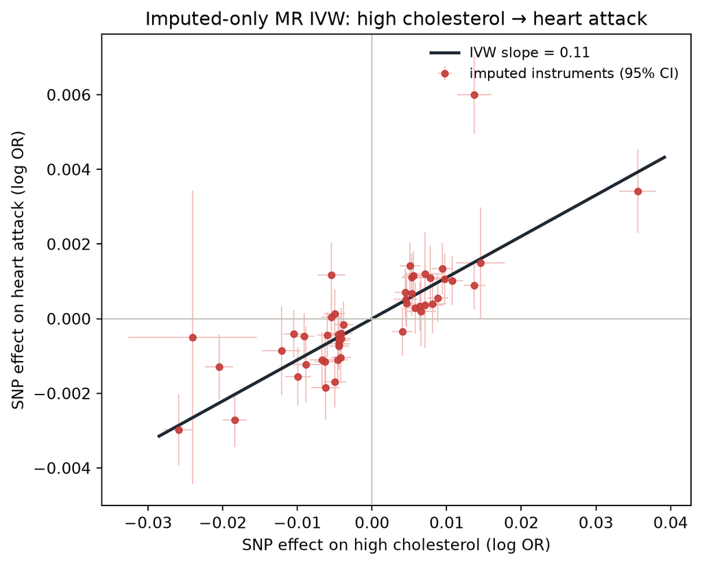

Imputed-only per-instrument effects from the completed store: exposure (x) vs outcome (y), with 95% CIs and the IVW slope.

## Regional imputation sanity check

The 1 Mb regional check is centred on the strongest imputed high-cholesterol top hit in the completed store. The plot shows all high-cholesterol associations returned for that window, with imputed associations highlighted.

- **Analysis**: `ukb-b-10912` (Non-cancer illness code, self-reported: high cholesterol)
- **Region**: chr19:44,409,976-45,409,976 centred on `19:44909976:G:T` (z=28.53)
- **Associations plotted**: 4,017 total; 3,302 observed and 715 imputed.

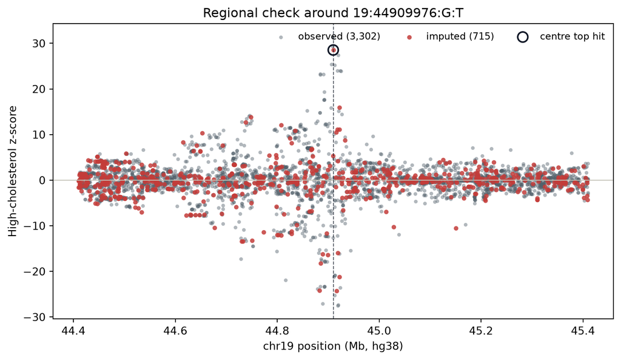

One megabase around the strongest imputed high-cholesterol top hit. Imputed associations are highlighted in red.

## Provenance

- Data: `opengwasdb_ukbb_dense_benchmark.json` and `opengwasdb_ukbb_dense_completed_benchmark.json` (from `benchmarks/benchmark_ukbb_dense.py`)
- Store: `/local-scratch/data/opengwas/opengwasdb/ukb-b.opengwasdb` (9,847,701 × 2,514)
- Completed store: `/local-scratch/data/opengwas/opengwasdb/ukb-b-c128-completed.opengwasdb` (11,192,757 × 2,514)
- MR is a demonstration/validation of the query layer, not a definitive epidemiological estimate (self-reported binary exposure, distance-based pruning in place of LD clumping).